# Libraries

```r
library(randomForest)
library(tidyverse)
library(knitr)
library(ggplot2)
library(here)
library(readr)
library(dplyr)
```

## 2.1 Dataset Overview

```r
access_healthcare <- read.csv("access-to-health-care_national_zaf.csv")
maternal_mortality <- read.csv( "maternal-mortality_national_zaf.csv")
immunization <- read.csv( "immunization_national_zaf.csv")
child_mortality <- read.csv ("child-mortality-rates_national_zaf.csv")

access_healthcare <- access_healthcare[-1, ]
child_mortality <- child_mortality[-1, ]
immunization <- immunization[-1, ]
maternal_mortality <- maternal_mortality[-1, ]
```

#Structure of datasets

```r
str(access_healthcare)
```

```
## 'data.frame':    275 obs. of  29 variables:
##  $ ISO3                  : chr  "ZAF" "ZAF" "ZAF" "ZAF" ...
##  $ DataId                : chr  "751751" "567476" "205488" "751748" ...
##  $ Indicator             : chr  "Antenatal care provider: Doctor" "Antenatal care provider: Doctor" "Antenatal care provider: Doctor" "Antenatal care provider: Nurse/midwife" ...
##  $ Value                 : chr  "28.5" "30" "27.3" "66.6" ...
##  $ Precision             : chr  "1" "1" "1" "1" ...
##  $ DHS_CountryCode       : chr  "ZA" "ZA" "ZA" "ZA" ...
##  $ CountryName           : chr  "South Africa" "South Africa" "South Africa" "South Africa" ...
##  $ SurveyYear            : chr  "1998" "1998" "1998" "1998" ...
##  $ SurveyId              : chr  "ZA1998DHS" "ZA1998DHS" "ZA1998DHS" "ZA1998DHS" ...
##  $ IndicatorId           : chr  "RH_ANCP_W_DOC" "RH_ANCP_W_DOC" "RH_ANCP_W_DOC" "RH_ANCP_W_NRS" ...
##  $ IndicatorOrder        : int  83363010 83363010 83363010 83363020 83363020 83363020 83363070 83363070 83363070 83363080 ...
##  $ IndicatorType         : chr  "I" "I" "I" "I" ...
##  $ CharacteristicId      : int  1000 1000 1000 1000 1000 1000 1000 1000 1000 1000 ...
##  $ CharacteristicOrder   : int  0 0 0 0 0 0 0 0 0 0 ...
##  $ CharacteristicCategory: chr  "Total" "Total" "Total" "Total" ...
##  $ CharacteristicLabel   : chr  "Total" "Total" "Total" "Total" ...
##  $ ByVariableId          : chr  "14000" "14001" "14002" "14000" ...
##  $ ByVariableLabel       : chr  "Three years preceding the survey" "Five years preceding the survey" "Two years preceding the survey" "Three years preceding the survey" ...
##  $ IsTotal               : int  1 1 1 1 1 1 1 1 1 1 ...
##  $ IsPreferred           : int  0 0 1 0 0 1 0 0 1 0 ...
##  $ SDRID                 : chr  "RHANCPWDOC" "RHANCPWDOC" "RHANCPWDOC" "RHANCPWNRS" ...
##  $ RegionId              : logi  NA NA NA NA NA NA ...
##  $ SurveyYearLabel       : int  1998 1998 1998 1998 1998 1998 1998 1998 1998 1998 ...
##  $ SurveyType            : chr  "DHS" "DHS" "DHS" "DHS" ...
##  $ DenominatorWeighted   : int  2871 4122 2010 2871 4122 2010 2871 4122 2010 2871 ...
##  $ DenominatorUnweighted : int  2903 4148 2041 2903 4148 2041 2903 4148 2041 2903 ...
##  $ CILow                 : logi  NA NA NA NA NA NA ...
##  $ CIHigh                : logi  NA NA NA NA NA NA ...
##  $ LevelRank             : logi  NA NA NA NA NA NA ...
```

```r
str(child_mortality)
```

```
## 'data.frame':    40 obs. of  29 variables:
##  $ ISO3                  : chr  "ZAF" "ZAF" "ZAF" "ZAF" ...
##  $ DataId                : chr  "85995" "794581" "785930" "56239" ...
##  $ Indicator             : chr  "Neonatal mortality rate (5 year periods)" "Postneonatal mortality (5 year periods)" "Infant mortality rate (5 year periods)" "Child mortality (5 year periods)" ...
##  $ Value                 : chr  "20" "26" "45" "15" ...
##  $ Precision             : chr  "0" "0" "0" "0" ...
##  $ DHS_CountryCode       : chr  "ZA" "ZA" "ZA" "ZA" ...
##  $ CountryName           : chr  "South Africa" "South Africa" "South Africa" "South Africa" ...
##  $ SurveyYear            : chr  "1998" "1998" "1998" "1998" ...
##  $ SurveyId              : chr  "ZA1998DHS" "ZA1998DHS" "ZA1998DHS" "ZA1998DHS" ...
##  $ IndicatorId           : chr  "CM_ECMT_C_NNR" "CM_ECMT_C_PNR" "CM_ECMT_C_IMR" "CM_ECMT_C_CMR" ...
##  $ IndicatorOrder        : int  63166010 63166020 63166030 63166040 63166050 63206010 63206010 63206020 63206020 63206030 ...
##  $ IndicatorType         : chr  "I" "I" "I" "I" ...
##  $ CharacteristicId      : int  13000 13000 13000 13000 13000 1000 1000 1000 1000 1000 ...
##  $ CharacteristicOrder   : int  80000 80000 80000 80000 80000 0 0 0 0 0 ...
##  $ CharacteristicCategory: chr  "Five year periods" "Five year periods" "Five year periods" "Five year periods" ...
##  $ CharacteristicLabel   : chr  "0-4" "0-4" "0-4" "0-4" ...
##  $ ByVariableId          : chr  "0" "0" "0" "0" ...
##  $ ByVariableLabel       : chr  "" "" "" "" ...
##  $ IsTotal               : int  1 1 1 1 1 1 1 1 1 1 ...
##  $ IsPreferred           : int  1 1 1 1 1 1 0 1 0 1 ...
##  $ SDRID                 : chr  "CMECMTCNNR" "CMECMTCPNR" "CMECMTCIMR" "CMECMTCCMR" ...
##  $ RegionId              : logi  NA NA NA NA NA NA ...
##  $ SurveyYearLabel       : int  1998 1998 1998 1998 1998 1998 1998 1998 1998 1998 ...
##  $ SurveyType            : chr  "DHS" "DHS" "DHS" "DHS" ...
##  $ DenominatorWeighted   : int  NA NA NA NA NA NA NA NA NA NA ...
##  $ DenominatorUnweighted : int  NA NA NA NA NA NA NA NA NA NA ...
##  $ CILow                 : int  15 20 38 9 50 15 16 20 19 38 ...
##  $ CIHigh                : int  25 31 53 20 68 25 23 31 27 53 ...
##  $ LevelRank             : logi  NA NA NA NA NA NA ...
```

```r
str(immunization)
```

```
## 'data.frame':    116 obs. of  29 variables:
##  $ ISO3                  : chr  "ZAF" "ZAF" "ZAF" "ZAF" ...
##  $ DataId                : chr  "330965" "139796" "330966" "139797" ...
##  $ Indicator             : chr  "BCG vaccination received" "BCG vaccination received" "DPT 1 vaccination received" "DPT 1 vaccination received" ...
##  $ Value                 : chr  "96.8" "94.9" "93.3" "93.1" ...
##  $ Precision             : chr  "1" "1" "1" "1" ...
##  $ DHS_CountryCode       : chr  "ZA" "ZA" "ZA" "ZA" ...
##  $ CountryName           : chr  "South Africa" "South Africa" "South Africa" "South Africa" ...
##  $ SurveyYear            : chr  "1998" "1998" "1998" "1998" ...
##  $ SurveyId              : chr  "ZA1998DHS" "ZA1998DHS" "ZA1998DHS" "ZA1998DHS" ...
##  $ IndicatorId           : chr  "CH_VACS_C_BCG" "CH_VACS_C_BCG" "CH_VACS_C_DP1" "CH_VACS_C_DP1" ...
##  $ IndicatorOrder        : int  93886010 93886010 93886020 93886020 93886030 93886030 93886040 93886040 93886050 93886050 ...
##  $ IndicatorType         : chr  "I" "I" "I" "I" ...
##  $ CharacteristicId      : int  268002 268002 268002 268002 268002 268002 268002 268002 268002 268002 ...
##  $ CharacteristicOrder   : int  268002 268002 268002 268002 268002 268002 268002 268002 268002 268002 ...
##  $ CharacteristicCategory: chr  "Source of vaccination information" "Source of vaccination information" "Source of vaccination information" "Source of vaccination information" ...
##  $ CharacteristicLabel   : chr  "Either source" "Either source" "Either source" "Either source" ...
##  $ ByVariableId          : chr  "258001" "258002" "258001" "258002" ...
##  $ ByVariableLabel       : chr  "12-23" "24-35" "12-23" "24-35" ...
##  $ IsTotal               : int  1 1 1 1 1 1 1 1 1 1 ...
##  $ IsPreferred           : int  1 0 1 0 1 0 1 0 1 0 ...
##  $ SDRID                 : chr  "CHVACSCBCG" "CHVACSCBCG" "CHVACSCDP1" "CHVACSCDP1" ...
##  $ RegionId              : logi  NA NA NA NA NA NA ...
##  $ SurveyYearLabel       : int  1998 1998 1998 1998 1998 1998 1998 1998 1998 1998 ...
##  $ SurveyType            : chr  "DHS" "DHS" "DHS" "DHS" ...
##  $ DenominatorWeighted   : int  973 933 973 933 973 933 973 933 973 933 ...
##  $ DenominatorUnweighted : int  971 951 971 951 971 951 971 951 971 951 ...
##  $ CILow                 : logi  NA NA NA NA NA NA ...
##  $ CIHigh                : logi  NA NA NA NA NA NA ...
##  $ LevelRank             : logi  NA NA NA NA NA NA ...
```

```r
str(maternal_mortality)
```

```
## 'data.frame':    21 obs. of  29 variables:
##  $ ISO3                  : chr  "ZAF" "ZAF" "ZAF" "ZAF" ...
##  $ DataId                : chr  "91409" "91377" "768646" "768647" ...
##  $ Indicator             : chr  "Female deaths that are pregnancy-related" "Number of pregnancy-related deaths" "Years of exposure to the risk of mortality for women" "Years of exposure to the risk of mortality for women (unweighted)" ...
##  $ Value                 : chr  "5.5" "19" "122701" "123738" ...
##  $ Precision             : chr  "1" "0" "0" "0" ...
##  $ DHS_CountryCode       : chr  "ZA" "ZA" "ZA" "ZA" ...
##  $ CountryName           : chr  "South Africa" "South Africa" "South Africa" "South Africa" ...
##  $ SurveyYear            : chr  "1998" "1998" "1998" "1998" ...
##  $ SurveyId              : chr  "ZA1998DHS" "ZA1998DHS" "ZA1998DHS" "ZA1998DHS" ...
##  $ IndicatorId           : chr  "MM_MMRT_W_FDP" "MM_MMRT_W_PDT" "MM_MMRT_W_EXP" "MM_MMRT_W_EXU" ...
##  $ IndicatorOrder        : int  77003010 77003020 77003030 77003040 77003050 77033010 77033020 77033030 77033040 77033050 ...
##  $ IndicatorType         : chr  "I" "N" "D" "U" ...
##  $ CharacteristicId      : int  10000 10000 10000 10000 10000 1000 1000 1000 1000 1000 ...
##  $ CharacteristicOrder   : int  10000 10000 10000 10000 10000 0 0 0 0 0 ...
##  $ CharacteristicCategory: chr  "Total 15-49" "Total 15-49" "Total 15-49" "Total 15-49" ...
##  $ CharacteristicLabel   : chr  "Total 15-49" "Total 15-49" "Total 15-49" "Total 15-49" ...
##  $ ByVariableId          : chr  "0" "0" "0" "0" ...
##  $ ByVariableLabel       : chr  "" "" "" "" ...
##  $ IsTotal               : int  1 1 1 1 1 1 1 1 1 1 ...
##  $ IsPreferred           : int  1 1 1 1 1 1 1 1 1 1 ...
##  $ SDRID                 : chr  "MMMMRTWFDP" "MMMMRTWPDT" "MMMMRTWEXP" "MMMMRTWEXU" ...
##  $ RegionId              : logi  NA NA NA NA NA NA ...
##  $ SurveyYearLabel       : int  1998 1998 1998 1998 1998 1998 1998 1998 1998 1998 ...
##  $ SurveyType            : chr  "DHS" "DHS" "DHS" "DHS" ...
##  $ DenominatorWeighted   : int  NA NA NA NA 122701 NA NA NA NA NA ...
##  $ DenominatorUnweighted : int  NA NA 123738 123738 123738 NA NA NA NA NA ...
##  $ CILow                 : int  NA NA NA NA NA NA 77 NA NA NA ...
##  $ CIHigh                : int  NA NA NA NA NA NA 223 NA NA NA ...
##  $ LevelRank             : logi  NA NA NA NA NA NA ...
```

#Dimensionality of data

```r
dim(access_healthcare)
```

```
## [1] 275  29
```

```r
dim(child_mortality)
```

```
## [1] 40 29
```

```r
dim(immunization)
```

```
## [1] 116  29
```

```r
dim(maternal_mortality)
```

```
## [1] 21 29
```

#Inspecting first few rows

```r
head(access_healthcare)
```

```
##   ISO3 DataId                              Indicator Value Precision
## 2  ZAF 751751        Antenatal care provider: Doctor  28.5         1
## 3  ZAF 567476        Antenatal care provider: Doctor    30         1
## 4  ZAF 205488        Antenatal care provider: Doctor  27.3         1
## 5  ZAF 751748 Antenatal care provider: Nurse/midwife  66.6         1
## 6  ZAF 567472 Antenatal care provider: Nurse/midwife    65         1
## 7  ZAF 205485 Antenatal care provider: Nurse/midwife  68.4         1
##   DHS_CountryCode  CountryName SurveyYear  SurveyId   IndicatorId
## 2              ZA South Africa       1998 ZA1998DHS RH_ANCP_W_DOC
## 3              ZA South Africa       1998 ZA1998DHS RH_ANCP_W_DOC
## 4              ZA South Africa       1998 ZA1998DHS RH_ANCP_W_DOC
## 5              ZA South Africa       1998 ZA1998DHS RH_ANCP_W_NRS
## 6              ZA South Africa       1998 ZA1998DHS RH_ANCP_W_NRS
## 7              ZA South Africa       1998 ZA1998DHS RH_ANCP_W_NRS
##   IndicatorOrder IndicatorType CharacteristicId CharacteristicOrder
```

[output cut: 34 more lines]

```r
head(child_mortality)
```

```
##   ISO3 DataId                                  Indicator Value Precision
## 2  ZAF  85995   Neonatal mortality rate (5 year periods)    20         0
## 3  ZAF 794581    Postneonatal mortality (5 year periods)    26         0
## 4  ZAF 785930     Infant mortality rate (5 year periods)    45         0
## 5  ZAF  56239           Child mortality (5 year periods)    15         0
## 6  ZAF 101014 Under-five mortality rate (5 year periods)    59         0
## 7  ZAF  83222                    Neonatal mortality rate    20         0
##   DHS_CountryCode  CountryName SurveyYear  SurveyId   IndicatorId
## 2              ZA South Africa       1998 ZA1998DHS CM_ECMT_C_NNR
## 3              ZA South Africa       1998 ZA1998DHS CM_ECMT_C_PNR
## 4              ZA South Africa       1998 ZA1998DHS CM_ECMT_C_IMR
## 5              ZA South Africa       1998 ZA1998DHS CM_ECMT_C_CMR
## 6              ZA South Africa       1998 ZA1998DHS CM_ECMT_C_U5M
## 7              ZA South Africa       1998 ZA1998DHS CM_ECMR_C_NNR
##   IndicatorOrder IndicatorType CharacteristicId CharacteristicOrder
```

[output cut: 34 more lines]

```r
head(immunization)
```

```
##   ISO3 DataId                  Indicator Value Precision DHS_CountryCode
## 2  ZAF 330965   BCG vaccination received  96.8         1              ZA
## 3  ZAF 139796   BCG vaccination received  94.9         1              ZA
## 4  ZAF 330966 DPT 1 vaccination received  93.3         1              ZA
## 5  ZAF 139797 DPT 1 vaccination received  93.1         1              ZA
## 6  ZAF 330967 DPT 2 vaccination received  86.2         1              ZA
## 7  ZAF 139798 DPT 2 vaccination received  82.4         1              ZA
##    CountryName SurveyYear  SurveyId   IndicatorId IndicatorOrder IndicatorType
## 2 South Africa       1998 ZA1998DHS CH_VACS_C_BCG       93886010             I
## 3 South Africa       1998 ZA1998DHS CH_VACS_C_BCG       93886010             I
## 4 South Africa       1998 ZA1998DHS CH_VACS_C_DP1       93886020             I
## 5 South Africa       1998 ZA1998DHS CH_VACS_C_DP1       93886020             I
## 6 South Africa       1998 ZA1998DHS CH_VACS_C_DP2       93886030             I
## 7 South Africa       1998 ZA1998DHS CH_VACS_C_DP2       93886030             I
##   CharacteristicId CharacteristicOrder            CharacteristicCategory
```

[output cut: 27 more lines]

```r
head(maternal_mortality)
```

```
##   ISO3 DataId                                                         Indicator
## 2  ZAF  91409                          Female deaths that are pregnancy-related
## 3  ZAF  91377                                Number of pregnancy-related deaths
## 4  ZAF 768646              Years of exposure to the risk of mortality for women
## 5  ZAF 768647 Years of exposure to the risk of mortality for women (unweighted)
## 6  ZAF 535566                                  Pregnancy-related mortality rate
## 7  ZAF 796695                                            General fertility rate
##    Value Precision DHS_CountryCode  CountryName SurveyYear  SurveyId
## 2    5.5         1              ZA South Africa       1998 ZA1998DHS
## 3     19         0              ZA South Africa       1998 ZA1998DHS
## 4 122701         0              ZA South Africa       1998 ZA1998DHS
## 5 123738         0              ZA South Africa       1998 ZA1998DHS
## 6   0.15         2              ZA South Africa       1998 ZA1998DHS
## 7     97         0              ZA South Africa       1998 ZA1998DHS
##     IndicatorId IndicatorOrder IndicatorType CharacteristicId
```

[output cut: 27 more lines]

#Opens up view

```r
view(access_healthcare)
view(maternal_mortality)
view(immunization)
view(child_mortality)
```

#Chnages data types

```r
#Changing Data types

#Convert value to numeric
access_healthcare$Value <- as.numeric(as.character(access_healthcare$Value))
child_mortality$Value <- as.numeric(as.character(child_mortality$Value))
immunization$Value <- as.numeric(as.character(immunization$Value))
maternal_mortality$Value <- as.numeric(as.character(maternal_mortality$Value))

#Convert Precision to numeric
access_healthcare$Precision <- as.numeric(as.character(access_healthcare$Precision))
child_mortality$Precision <- as.numeric(as.character(child_mortality$Precision))
immunization$Precision <- as.numeric(as.character(immunization$Precision))
maternal_mortality$Precision <- as.numeric(as.character(maternal_mortality$Precision))

#Convert CharacteristicId to character
access_healthcare$CharacteristicId <- as.character(as.numeric(access_healthcare$CharacteristicId))
child_mortality$CharacteristicId <- as.character(as.numeric(child_mortality$CharacteristicId))
immunization$CharacteristicId <- as.character(as.numeric(immunization$CharacteristicId))
maternal_mortality$CharacteristicId <- as.character(as.numeric(maternal_mortality$CharacteristicId))



# Convert SurveyYear to numeric for plots
access_healthcare$SurveyYear <- as.numeric(access_healthcare$SurveyYear)
child_mortality$SurveyYear <- as.numeric(child_mortality$SurveyYear)
immunization$SurveyYear <- as.numeric(immunization$SurveyYear)
maternal_mortality$SurveyYear <- as.numeric(maternal_mortality$SurveyYear)
```

#Sum of verious data

```r
print('summary of Health care value')
```

```
## [1] "summary of Health care value"
```

```r
summary(access_healthcare$Value)
```

```
##    Min. 1st Qu.  Median    Mean 3rd Qu.    Max.
##     0.0     7.6    67.6   542.7   100.0  5066.0
```

```r
print('summary of Child Mortality value')
```

```
## [1] "summary of Child Mortality value"
```

```r
summary(child_mortality$Value)
```

```
##    Min. 1st Qu.  Median    Mean 3rd Qu.    Max.
##    7.00   19.75   35.00  466.85   52.50 5183.00
```

```r
print('summary of immunization value')
```

```
## [1] "summary of immunization value"
```

```r
summary(immunization$Value)
```

```
##    Min. 1st Qu.  Median    Mean 3rd Qu.    Max.
##    2.20   65.60   82.55  234.95   91.25 3761.00
```

```r
print('summary of  maternal mortality value')
```

```
## [1] "summary of  maternal mortality value"
```

```r
summary(maternal_mortality$Value)
```

```
##      Min.   1st Qu.    Median      Mean   3rd Qu.      Max.
## 5.000e-03 7.800e+00 9.700e+01 1.788e+04 5.360e+02 1.237e+05
```

```r
print('Missing Values')
```

```
## [1] "Missing Values"
```

```r
sum(is.na(access_healthcare))
```

```
## [1] 1168
```

```r
sum(is.na(child_mortality))
```

```
## [1] 172
```

```r
sum(is.na(immunization))
```

```
## [1] 480
```

```r
sum(is.na(maternal_mortality))
```

```
## [1] 112
```

```r
print('Duplicate values')
```

```
## [1] "Duplicate values"
```

```r
sum(duplicated(access_healthcare))
```

```
## [1] 0
```

```r
sum(duplicated(child_mortality))
```

```
## [1] 0
```

```r
sum(duplicated(immunization))
```

```
## [1] 0
```

```r
sum(duplicated(maternal_mortality))
```

```
## [1] 0
```

#Visuals of data

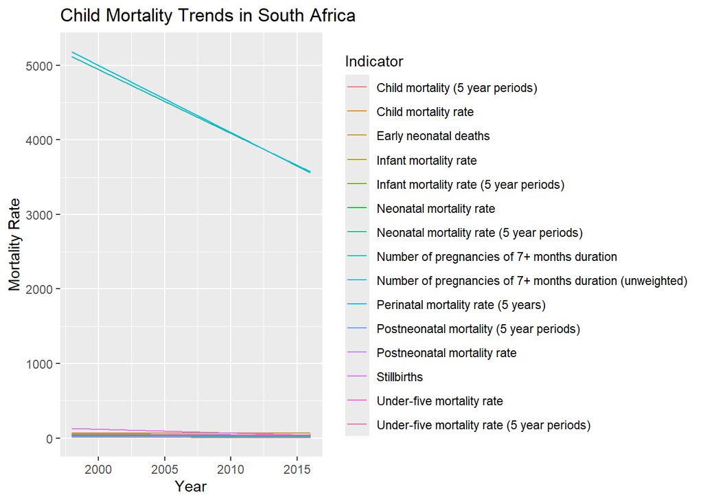

```r
# Plot child mortality over time
ggplot(child_mortality, aes(x = SurveyYear, y = as.numeric(Value), color = Indicator)) +
  geom_line() +
  labs(title = "Child Mortality Trends in South Africa", x = "Year", y = "Mortality Rate")
```

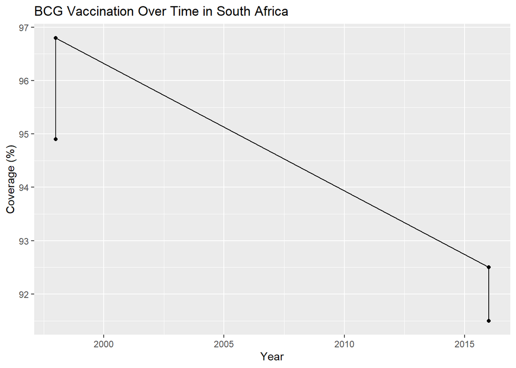

```r
# Line chart of BCG vaccination over time
ggplot(filter(immunization, Indicator == "BCG vaccination received"),
       aes(x = SurveyYear, y = Value)) +
  geom_line() +
  geom_point() +
  labs(title = "BCG Vaccination Over Time in South Africa",
       x = "Year", y = "Coverage (%)")
```

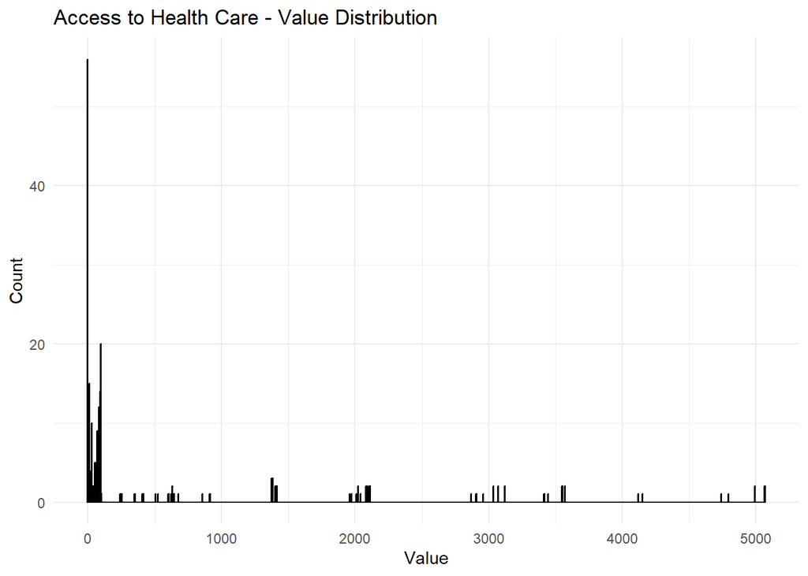

```r
#Access to Health Care - Value Distribution
ggplot(access_healthcare, aes(x = Value)) +
  geom_histogram(binwidth = 5, fill = "yellow", color = "black") +
  labs(title = "Access to Health Care - Value Distribution", x = "Value", y = "Count") +
  theme_minimal()
```

```r
data_model <- child_mortality[
  child_mortality$Indicator == "Under-five mortality rate",
  c("SurveyYear", "Value")
]

# Remove missing values
data_model <- data_model[complete.cases(data_model), ]

# Remove duplicate rows
data_model <- unique(data_model)

# Sort by SurveyYear
data_model <- data_model[order(data_model$SurveyYear), ]

print(data_model)
```

```
##    SurveyYear Value
## 15       1998    59
## 16       1998    57
## 35       2016    42
## 36       2016    51
```

##Random Forest Model Version 2

```r
# Set a seed for reproducibility so the results are consistent.
set.seed(42) #changing seed data changes results

# Create a sample of row indices for the training data //Use of percentage either 0.7(70)or 0.5(50)
train_indices <- sample(1:nrow(data_model), 0.5 * nrow(data_model))

# Split the data into training and testing sets based on the indices
train_data <- data_model[train_indices, ]
test_data <- data_model[-train_indices, ]

# --- 3. Build the Random Forest Model ---
rf_model <- randomForest(
  Value ~ SurveyYear,
  data = train_data,
  ntree = 500, # Number of trees in the forest
  mtry = 1,    # Number of variables to sample at each split
  importance = TRUE # Calculate and store variable importance
)
# Print the model summary
print("Random Forest Model Summary:")
```

```
## [1] "Random Forest Model Summary:"
```

```r
print(rf_model)
```

```
##
## Call:
##  randomForest(formula = Value ~ SurveyYear, data = train_data,      ntree = 500, mtry = 1, importance = TRUE)
##                Type of random forest: regression
##                      Number of trees: 500
## No. of variables tried at each split: 1
##
##           Mean of squared residuals: 64
##                     % Var explained: -300
```

```r
# --- 4. Make Predictions ---

# Use the trained model to make predictions on the test data.
predictions <- predict(rf_model, newdata = test_data)

# Combine the test data and predictions for comparison
results <- data.frame(
  Actual = test_data$Value,
  Predicted = predictions,
  SurveyYear = test_data$SurveyYear
)

# --- 5. Evaluate the Model ---

# Calculate the Mean Absolute Error (MAE) to measure prediction accuracy.
mae <- mean(abs(results$Actual - results$Predicted))
print(paste("Mean Absolute Error (MAE):", round(mae, 2)))
```

```
## [1] "Mean Absolute Error (MAE): 5.62"
```

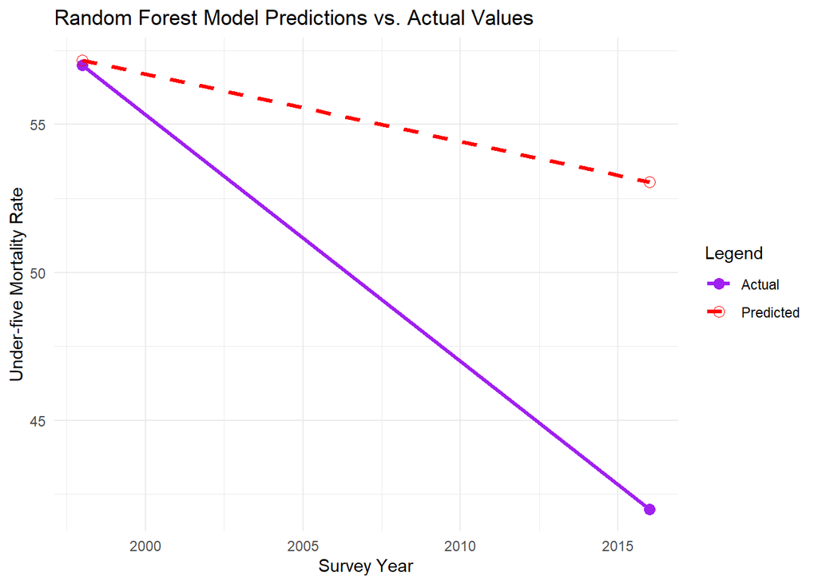

```r
# Visualize the results
# Plot the actual vs. predicted values to see how well the model fits the data.
ggplot(results, aes(x = SurveyYear)) +
  geom_line(aes(y = Actual, color = "Actual"), linewidth = 1.2) +
  geom_point(aes(y = Actual, color = "Actual"), size = 3) +
  geom_line(aes(y = Predicted, color = "Predicted"), linetype = "dashed", linewidth = 1.2) +
  geom_point(aes(y = Predicted, color = "Predicted"), shape = 1, size = 3) +
  labs(
    title = "Random Forest Model Predictions vs. Actual Values",
    x = "Survey Year",
    y = "Under-five Mortality Rate",
    color = "Legend"
  ) +
  scale_color_manual(values = c("Actual" = "purple", "Predicted" = "red")) +
  theme_minimal()
```

##Validation set

```r
set.seed(42)
n <- nrow(data_model)
indices <- sample(1:n)

train_end <- floor(0.7 * n)
valid_end <- floor(0.9 * n)

train_indices <- indices[1:train_end]
valid_indices <- indices[(train_end + 1):valid_end]
test_indices  <- indices[(valid_end + 1):n]

train_data <- data_model[train_indices, ]
valid_data <- data_model[valid_indices, ]
test_data  <- data_model[test_indices, ]
```

##wprk around Cross-validation procedure

```r
## Random Forest Regression
train_data$Value <- as.numeric(train_data$Value)
test_data$Value  <- as.numeric(test_data$Value)

rf_model <- randomForest(Value ~ SurveyYear, data = train_data, ntree = 500, mtry = 1)
print(rf_model)
```

```
##
## Call:
##  randomForest(formula = Value ~ SurveyYear, data = train_data,      ntree = 500, mtry = 1)
##                Type of random forest: regression
##                      Number of trees: 500
## No. of variables tried at each split: 1
##
##           Mean of squared residuals: 64
##                     % Var explained: -300
```

```r
# Predictions
preds <- predict(rf_model, newdata = test_data)

# Results + Metrics
results <- data.frame(
  Actual = test_data$Value,
  Predicted = preds
)

mae  <- mean(abs(results$Actual - results$Predicted))
rmse <- sqrt(mean((results$Actual - results$Predicted)^2))
r2   <- cor(results$Actual, results$Predicted)^2

print(paste("MAE:", round(mae, 2)))
```

```
## [1] "MAE: 0.16"
```

```r
print(paste("RMSE:", round(rmse, 2)))
```

```
## [1] "RMSE: 0.16"
```

```r
print(paste("R-squared:", round(r2, 2)))
```

```
## [1] "R-squared: NA"
```

## 3. Random Forest Model for Under-five Mortality

This section implements a Random Forest regression model to predict **under-five child mortality** in South Africa using survey year as the predictor.

### 3.1 Model Overview

Random Forest is an ensemble learning method that constructs multiple decision trees and aggregates their predictions to improve accuracy and reduce overfitting.  
**Strengths:** Handles non-linear relationships, robust to outliers, provides variable importance.  
**Limitations:** Less interpretable than single decision trees, requires parameter tuning, can be computationally intensive.

### 3.2 Data Preparation

```r
# Filter dataset for the target indicator
data_model <- child_mortality %>%
  filter(Indicator == "Under-five mortality rate") %>%
  select(SurveyYear, Value) %>%
  mutate(Value = as.numeric(Value)) %>%
  unique() %>%
  arrange(SurveyYear)

# Split into training (70%) and test (30%) sets
set.seed(123)
train_index <- sample(1:nrow(data_model), 0.7 * nrow(data_model))
train_data <- data_model[train_index, ]
test_data  <- data_model[-train_index, ]
```

### 3.3 Model Building

We use 500 trees (ntree = 500) to ensure stability in predictions and mtry = 1 because there is only one predictor. Minimum node size (nodesize = 5) controls tree depth to prevent overfitting.

```r
rf_model <- randomForest(
  Value ~ SurveyYear,
  data = train_data,
  ntree = 500,
  mtry = 1,
  nodesize = 5,
  importance = TRUE
)
# Model summary
print(rf_model)
```

```
##
## Call:
##  randomForest(formula = Value ~ SurveyYear, data = train_data,      ntree = 500, mtry = 1, nodesize = 5, importance = TRUE)
##                Type of random forest: regression
##                      Number of trees: 500
## No. of variables tried at each split: 1
##
##           Mean of squared residuals: 81
##                     % Var explained: -300
```

### 3.4 Predictions and Evaluation

```r
# Predictions on test data
predictions <- predict(rf_model, newdata = test_data)

# Evaluation metrics
MAE  <- mean(abs(predictions - test_data$Value))
RMSE <- sqrt(mean((predictions - test_data$Value)^2))
R2   <- 1 - sum((test_data$Value - predictions)^2) / sum((test_data$Value - mean(test_data$Value))^2)

cat("Mean Absolute Error (MAE):", round(MAE, 2), "\n")
```

```
## Mean Absolute Error (MAE): 11.63
```

```r
cat("Root Mean Squared Error (RMSE):", round(RMSE, 2), "\n")
```

```
## Root Mean Squared Error (RMSE): 11.67
```

```r
cat("R² (Coefficient of Determination):", round(R2, 2), "\n")
```

```
## R² (Coefficient of Determination): -135.16
```

## 4. Random Forest Regression: Under-five Mortality

This section uses a Random Forest regression to model and predict **under-five child mortality** in South Africa based on survey year.

### 4.1 Data Preparation

```r
#
data_model <- child_mortality %>%
  filter(Indicator == "Under-five mortality rate") %>%
  mutate(
    Value = as.numeric(Value),
    SurveyYear = as.numeric(SurveyYear)
  ) %>%
  group_by(SurveyYear) %>%
  summarise(Value = mean(Value)) %>%
  arrange(SurveyYear)

print(data_model)
```

```
## # A tibble: 2 × 2
##   SurveyYear Value
##        <dbl> <dbl>
## 1       1998  58
## 2       2016  46.5
```

```r
# Train/test split: 70% train, 30% test
set.seed(123)
rf_model <- randomForest(Value ~ SurveyYear, data = data_model, ntree = 500, mtry = 1)
predictions <- predict(rf_model, newdata = data_model)
```

### 4.2 Model Building

```r
rf_model <- randomForest(
  Value ~ SurveyYear,
  data = train_data,
  ntree = 500,   # number of trees
  mtry = 1,      # number of variables sampled per split
  nodesize = 5,  # minimum samples per terminal node
  importance = TRUE
)
print(rf_model)
```

```
##
## Call:
##  randomForest(formula = Value ~ SurveyYear, data = train_data,      ntree = 500, mtry = 1, nodesize = 5, importance = TRUE)
##                Type of random forest: regression
##                      Number of trees: 500
## No. of variables tried at each split: 1
##
##           Mean of squared residuals: 81
##                     % Var explained: -300
```

### 4.3 Predictions and Evaluation

```r
predictions <- predict(rf_model, newdata = test_data)

MAE  <- mean(abs(predictions - test_data$Value))
RMSE <- sqrt(mean((predictions - test_data$Value)^2))
R2   <- 1 - sum((test_data$Value - predictions)^2) / sum((test_data$Value - mean(test_data$Value))^2)

cat("Mean Absolute Error (MAE):", round(MAE, 2), "\n")
```

```
## Mean Absolute Error (MAE): 11.5
```

```r
cat("Root Mean Squared Error (RMSE):", round(RMSE, 2), "\n")
```

```
## Root Mean Squared Error (RMSE): 11.54
```

```r
cat("R² (Coefficient of Determination):", round(R2, 2), "\n")
```

```
## R² (Coefficient of Determination): -132.25
```

### 4.4 Results Visualization

```r
# Linear model (more appropriate for 2 points)
lm_model <- lm(Value ~ SurveyYear, data = data_model)
summary(lm_model)
```

```
##
## Call:
## lm(formula = Value ~ SurveyYear, data = data_model)
##
## Residuals:
## ALL 2 residuals are 0: no residual degrees of freedom!
##
## Coefficients:
##              Estimate Std. Error t value Pr(>|t|)
## (Intercept) 1334.5000        NaN     NaN      NaN
## SurveyYear    -0.6389        NaN     NaN      NaN
##
## Residual standard error: NaN on 0 degrees of freedom
## Multiple R-squared:      1,  Adjusted R-squared:    NaN
## F-statistic:   NaN on 1 and 0 DF,  p-value: NA
```

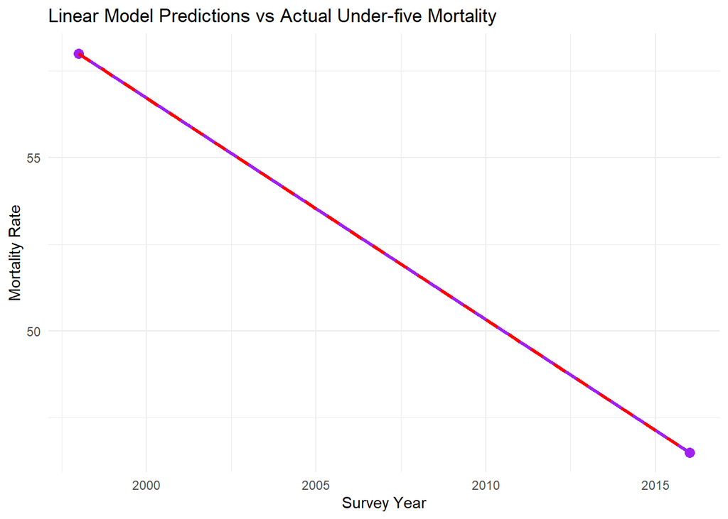

```r
# Predictions
predictions <- predict(lm_model, newdata = data_model)

# Plot
results <- data.frame(
  SurveyYear = data_model$SurveyYear,
  Actual = data_model$Value,
  Predicted = predictions
)

ggplot(results, aes(x = SurveyYear)) +
  geom_point(aes(y = Actual), color = "purple", size = 3) +
  geom_line(aes(y = Actual), color = "purple", linewidth = 1.2) +
  geom_line(aes(y = Predicted), color = "red", linetype = "dashed", linewidth = 1.2) +
  labs(
    title = "Linear Model Predictions vs Actual Under-five Mortality",
    x = "Survey Year",
    y = "Mortality Rate"
  ) +
  theme_minimal()
```

### 4.5 Variable Importance

```r
importance(rf_model)
```

```
##            %IncMSE IncNodePurity
## SurveyYear       0             0
```

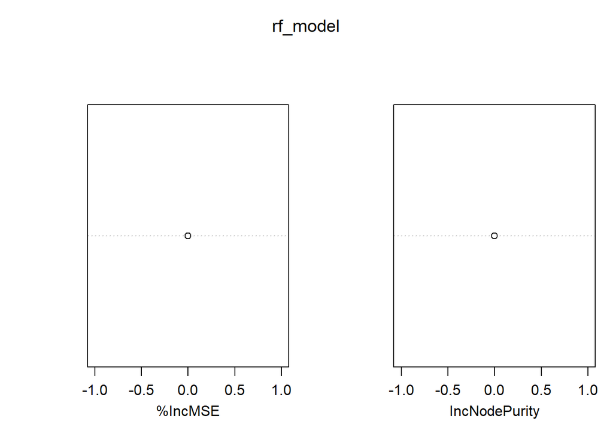

```r
varImpPlot(rf_model)
```

%IncMSE = 0 → No other variable to compare; permuting it doesn’t change the model much (because only one predictor exists).

IncNodePurity = 0 → Same reason; it’s the only variable, so the importance metrics aren’t meaningful.

Basically, variable importance is most useful when you have multiple predictors.